# RERConverge: walk-through of binary trait analysis

Wynn Meyer

10/17/2017

This walk-through provides instructions for implementing the RERConverge package to identify genes whose evolutionary rates shift in association with change in a binary trait. For information on how to download and install RERConverge, see the README on [github](https://github.com/nclark-lab/RERconverge).

As an example, we will run the code in the `runMarineSub` script in the vignettes folder.

## Reading in gene trees with `readTrees`

To run RERconverge, you will first need to supply a file containing **gene trees** for all genes to be included in your analysis. This is a tab delimited file with the following information on each line:

Gene_name Newick_tree

An example file is provided in *data/mammal62aa_meredplus_wCM.trees*, which you can view in any text editor.

In R, load the RERConverge library and read in the gene trees. The `readTrees` function takes quite a while to read in trees for all genes, so we will limit ourselves to the first 200 using `max.read` (this will still take a minute or so, so be patient):

```r
#library(devtools)
#install_github("nclark-lab/RERconverge")
#library("RERconverge")
#This is a temporary alternative to using library
#(these are the latest versions of the scripts).
source('../R/enrichmentFuncs.R')
source('../R/plottingFuncs.R')
source('../R/projection_coevo.R')
source('../R/RERfuncs.R')
source('../R/coordsfn.R')
```

```r
mamTrees=readTrees("../data/mammal62aa_meredplus_wCM.trees", max.read = 200)
```

```
## max is  62
```

```
## estimating master tree branch lengths from 32 genes
```

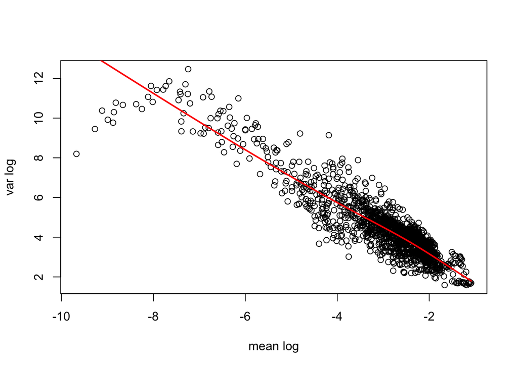

First, the code tells us that the maximum number of tips in the gene trees is 62. It then reports that it will use the 32 genes in this set that have data for all 62 species to estimate a **master tree**. The tree topology for the master tree (but not its branch lengths) will be used for subsequent analyses.

The figure here is a log-scale plot of the variance versus the mean for all possible branch lengths in the tree, summarized across all genes in the dataset. Where the relationship between mean and variance starts to break down for very small values (in this case very large negative values) can be an indicator of the point at which values are too close to zero to provide accurate information for analyses. In our example plot, this happens around $e^{-7}$. We use approximately this value as our cutoff to exclude short branches in further analyses.

## Estimating relative evolutionary rates (RER) with `getAllResiduals`

The next step is to estimate **relative evolutionary rates**, or RER, for all branches in the tree for each gene. Intuitively, a gene’s RER for a given branch represents how quickly or slowly the gene is evolving on that branch, relative to its overall rate of evolution throughout the tree. For more details about how RER are computed, see (Chikina, Robinson, and Clark 2016) and (Partha et al. 2017).

We will use the `getAllResiduals` function to calculate RER. This uses the following input variables:

- `useSpecies`: a vector that can be used to specify a subset of species to use in the analysis. Here we will use the full set of tip labels in the master tree (this is also the default, if `useSpecies` is not set).
- `transform`: the method used to transform the raw data. By transforming the raw data, we reduce the heteroscedasticity (relationship between mean and variance) and the influence of outliers. Here we will use a square-root transform.
- `weighted`: whether to use a weighted regression to estimate RER. Weighting allows further correction for the relationship between mean and variance, which can be directly estimated from the data. We recommend it and will use it here.
- `cutoff`: minimum branch length for inclusion (see above for estimating a reasonable cutoff from the mean-variance plot). Here we will filter any branches shorter than 0.001. Here is the basic method, with the recommended settings:

```r
mamRER=getAllResiduals(mamTrees,useSpecies=mamTrees$masterTree$tip.label,
                           transform = "sqrt", weighted = T, cutoff=0.001)
```

While this is running, it will print out *i=N* for a series of numbers. This shows how many genes have had RER estimated.

We can visualize the RERs for any given gene using the `plotRers` function. Here is an example.

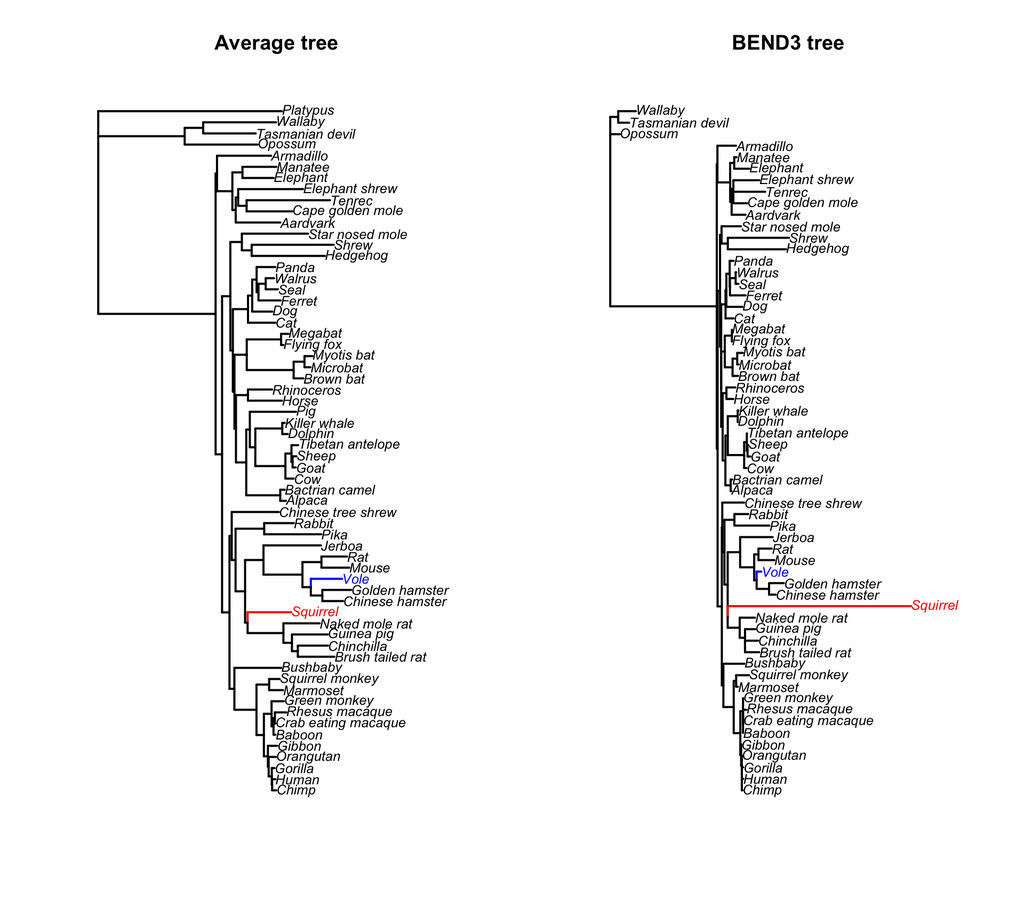

```r
#make average and gene tree plots
noneutherians <- c("Platypus","Wallaby","Tasmanian_devil","Opossum")
par(mfrow=c(1,2))
avgtree=plotTreeHighlightBranches(mamTrees$masterTree, outgroup=noneutherians, hlspecies=c("Vole","Squirrel"), hlcols=c("blue","red"), main="Average tree") #plot average tree
bend3tree=plotTreeHighlightBranches(mamTrees$trees$BEND3, outgroup=noneutherians, hlspecies=c("Vole","Squirrel"), hlcols=c("blue","red"), main="BEND3 tree") #plot individual gene tree
```

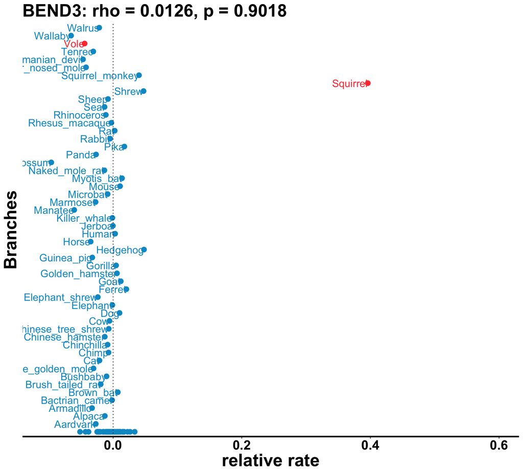

```r
#plot RERs
par(mfrow=c(1,1))
phenvExample <- foreground2Paths(c("Vole","Squirrel"),mamTrees)
plotRers(mamRER,"BEND3",phenv=phenvExample) #plot RERs
```

The upper left plot is a tree with branch lengths representing the average rates across all genes. The upper right plot is the same tree, but with branch lengths representing rates specifically for the BEND3 gene. The plot below these represents the estimated RERs for terminal branches. The foreground branches (set here using `foreground2Paths`) are highlighted in red. Notice how the RER for vole is negative; this is because the branch leading to vole in the BEND3 tree is shorter than average. On the other hand, the RER for squirrel is positive because the branch leading to squirrel in the BEND3 tree is longer than average.

## Reading in or generating trait trees

Now we will associate variation in these RERs with variation in traits across the tree. To do so, we first need to provide information about which branches of the tree have the trait of interest (**foreground branches**). There are three possible ways to do this:

1. Provide a binary trait tree file. This should be a file in Newick format with branch lengths zero for background branches and one for foreground branches. An example is provided in *data/MarineTreeBin.txt*.

```r
marineb=read.tree("../data/MarineTreeBinCommonNames.txt")
marinebrooted = root(marineb,outgroup=noneutherians)
```

This tree file has all extant marine species, plus the ancestor of the killer whale and the dolphin, as foreground.

2. Use the interactive branch selection tool. The following should open a plot of the master tree. When the GUI opens, select the marine foreground branches (Walrus, Seal, Killer whale, Dolphin, Killer whale-Dolphin ancestor, and Manatee), and click ‘End selection.’

```r
marineb2=selectforegroundbranches(mamTrees$masterTree)
```

3. Provide a list of species to use as foreground species. This only allows inclusion of extant lineages, so in this case, the Killer whale-Dolphin ancestor will no longer be included.

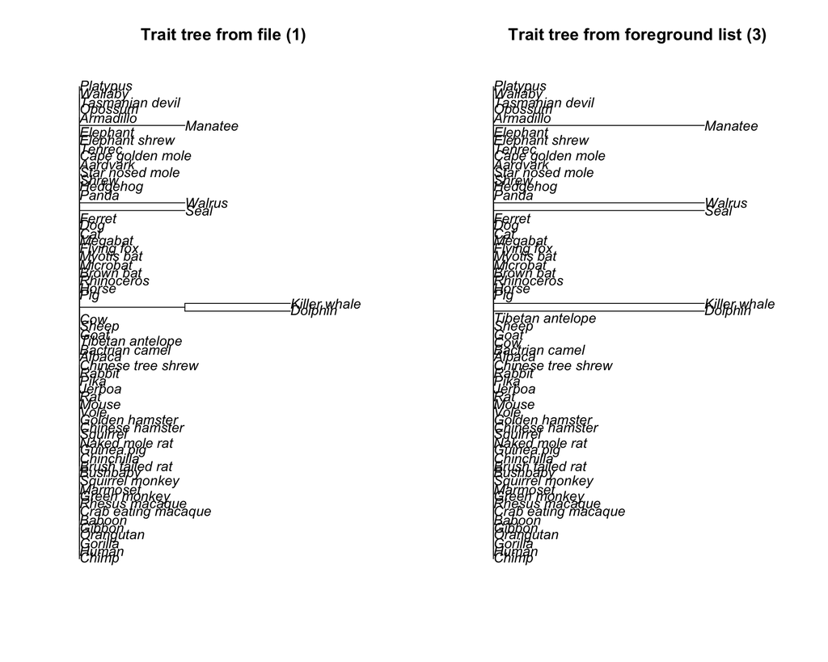

```r
marineextantforeground = c("Walrus","Seal","Killer_whale","Dolphin","Manatee")
masterrooted <- root(mamTrees$masterTree,outgroup=noneutherians)
wspmr <- masterrooted$tip.label[masterrooted$edge[,2]]
wmarine <- which(wspmr %in% marineextantforeground)
marineb3rooted <- masterrooted
marineb3rooted$edge.length <- c(rep(0,length(marineb3rooted$edge.length)))
marineb3rooted$edge.length[wmarine] <- 1
par(mfrow=c(1,2))
plot(marinebrooted, main="Trait tree from file (1)")
plot(marineb3rooted, main="Trait tree from foreground list (3)")
```

Note that the branch representing the ancestor of the killer whale and the dolphin has a branch length of 1 in the tree on the left and a branch length of 0 in the tree on the right. As mentioned, providing a binary trait tree file (1) or manually specifying foreground branches (2) allows you to include internal branches in the foreground, whereas specifying a list of foreground species (3) does not.

You can double check that the tree you created by manual selection (2) matches the tree above on the left (it should) using the following code:

```r
marineb2=selectforegroundbranches(mamTrees$masterTree)
marineb2rooted=root(marineb2,outgroup=c("Platypus", "Wallaby","Tasmanian_devil","Opossum"))
plot(marineb2rooted, main = "Trait tree from manual selection (2)")
```

## Generating **paths** for all genes using `tree2Paths` or `foreground2Paths`

Some of the genes (like BEND3 above) may not have data for all species, meaning that their phylogeny will be a subset of the full phylogeny. To plot RERs for these genes and to correlate them with trait evolution, we run one of two functions that determine how the trait would evolve along all/many possible subsets of the full phylogeny, generating a set of **paths**. The function `tree2paths` takes a binary tree as input, and the function `foreground2paths` takes a set of foreground species as input.

```r
phenvMarine=tree2Paths(marineb, mamTrees)
phenvMarine2=foreground2Paths(marineextantforeground, mamTrees)
```

## Correlating gene evolution with trait evolution using `getAllCor`

Now that we have estimates for the RERs for all genes of interest, as well as a representation of how the trait of interest evolves across the tree, we can use RERConverge to test for an association between relative evolutionary rate and trait across all branches of the tree.

```r
corMarine=getAllCor(mamRER, phenvMarine)
```

```
## Setting method to Kendall
```

The `getAllCor` function generates a table with the following output for each gene:

1. Rho: the correlation between relative evolutionary rate and trait across all branches
2. N: the number of branches in the gene tree
3. P: an estimate of the P-value for association between relative evolutionary rate and trait.

Let’s take a look at some of the top genes within this set.

```r
head(corMarine[order(corMarine$P),])
```

```
##                 Rho   N           P
## ANO2      0.2341120 107 0.003299741
## BDH1      0.2356080 103 0.003728470
## BMP10    -0.2321062 105 0.003910427
## ATP2A1    0.2094293 103 0.009937010
## AK124326 -0.2560822  69 0.010235712
## ARPP19   -0.3845453  31 0.011117561
```

ANO2 and BMP10 are two of the top genes.

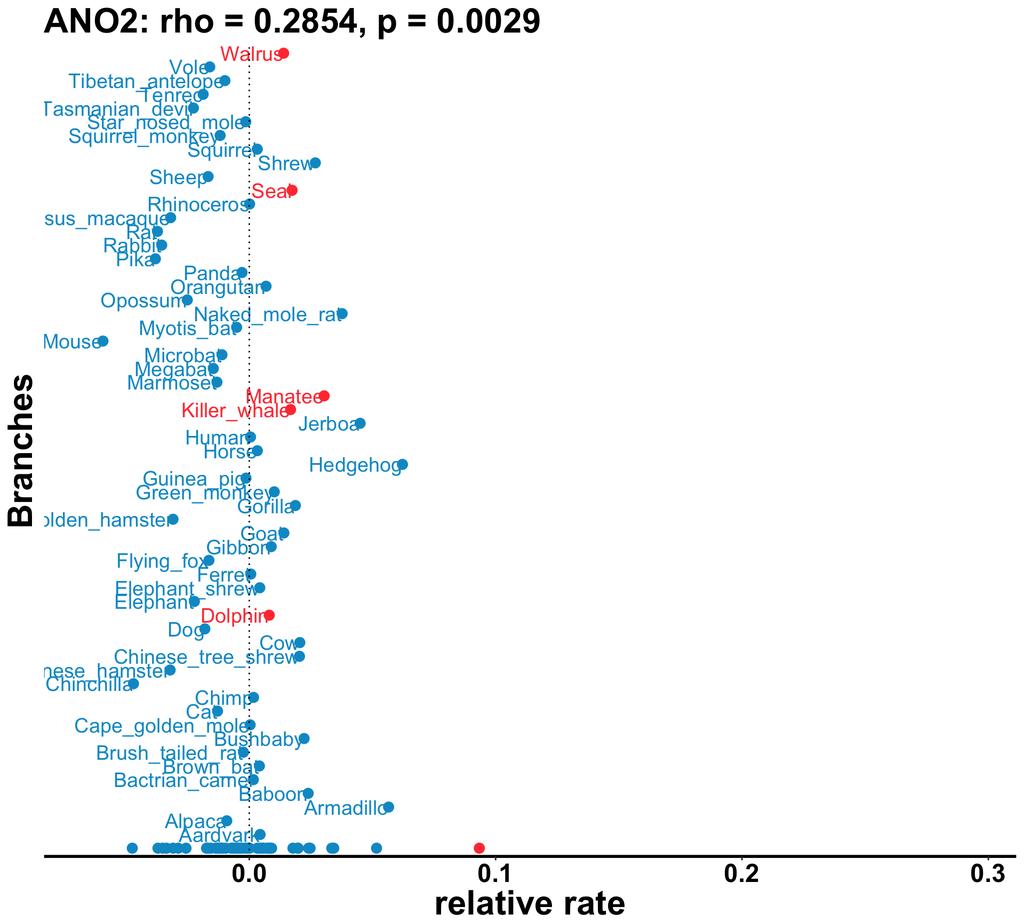

```r
plotRers(mamRER,"ANO2",phenv=phenvMarine)
```

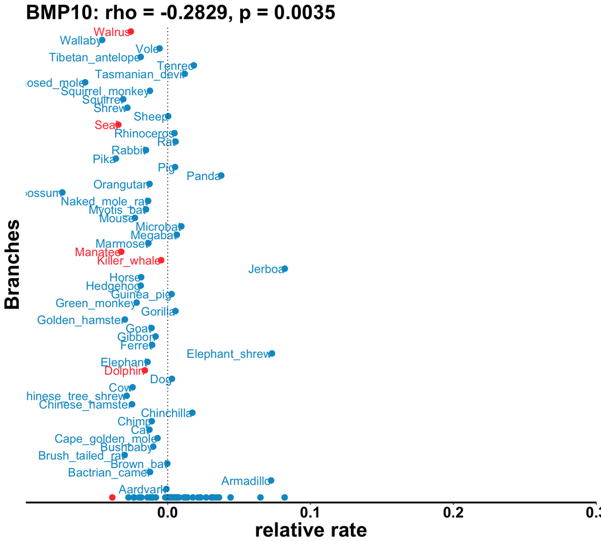

```r
plotRers(mamRER,"BMP10",phenv=phenvMarine)
```

In these RER plots, the marine lineages specified in the foreground are highlighted in red. The terminal branches are listed in alphabetical order, and internal branches are displayed at the bottom; note the red point at the bottom of each plot indicating the RER for killer whale-dolphin ancestral branch.

In the ANO2 tree, marine lineages have high RER, leading to a positive Rho and a low p-value. In contrast, in the BMP10 tree, marine lineages have low RER. This also yields a low p-value, but with a negative Rho.

To see what the overall pattern of association is across all genes in the set, we can plot a p-value histogram.

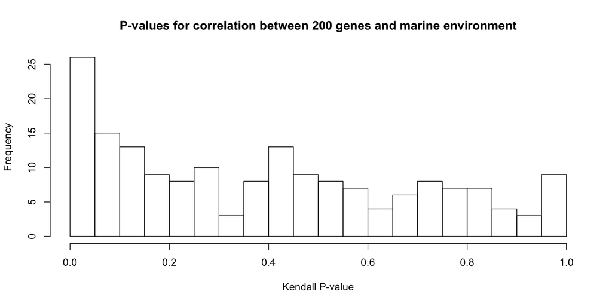

```r
hist(corMarine$P, breaks=15, xlab="Kendall P-value",
     main="P-values for correlation between 200 genes and marine environment")
```

There appears to be a slight enrichment of low p-values, but since we have only evaluated the first 200 genes from our ~19,000 gene genome-wide set, we should hold off on drawing conclusions from this.

## Conclusion

We’ve now walked through the basic workflow for RERConverge. For more information about these methods and some results relevant to marine and subterranean adaptation, see (Chikina, Robinson, and Clark 2016) and (Partha et al. 2017).

# References

Chikina, Maria, Joseph D Robinson, and Nathan L Clark. 2016. “Hundreds of Genes Experienced Convergent Shifts in Selective Pressure in Marine Mammals.” *Molecular Biology and Evolution* 33 (9): 2182–92. doi:10.1093/molbev/msw112.

Partha, Raghavendran, Bharesh K Chauhan, Zelia Ferreira, Joseph D Robinson, Kira Lathrop, Ken K Nischal, Maria Chikina, and Nathan L Clark. 2017. “Subterranean mammals show convergent regression in ocular genes and enhancers, along with adaptation to tunneling.” *ELife* 6 (October). eLife Sciences Publications Limited: e25884. doi:10.7554/eLife.25884.